# Python语言程序设计（实验）——Seaborn 基础教程

## Part 1. 什么是 Seaborn

`Seaborn` 是基于 `Matplotlib` 封装开发的高级绘图库，主要用于统计图表的绘制。它能够与 Pandas 数据结构紧密配合，让你用更少的代码完成更漂亮的图形输出。

### Seaborn 的优势

- 与 Pandas 深度集成，可直接使用 DataFrame 进行绘图；
- 提供丰富的统计图表类型，一行代码即可完成分组平均、误差分析等任务；
- 默认图形风格美观统一，减少繁琐设置；
- 支持分类变量、高维变量（如 `hue`、`style`、`size`）的可视化；
- 兼容 Jupyter Notebook，自适应布局，无需手动 `plt.show()`。

### Seaborn 的典型应用场景

- 科学计算、数据分析、机器学习中的数据探索（EDA）
- 对分类变量、数值变量、聚类分布等关系的可视化分析
- 快速构建分组图表，用于结果汇报或论文图示

在接下来的内容中，我们将系统介绍 Seaborn 的常用绘图函数及其参数用法，结合实际数据集完成多种统计图表的绘制。

## Part 2. Seaborn 的常用函数与样式设置

`Seaborn` 提供了大量常用图表函数，能够帮助我们快速完成统计图的绘制，特别适用于对 Pandas DataFrame 结构的数据进行分析与展示。

### 2.1 常用绘图函数总览

| 函数名 | 图表类型 | 用途说明 | 常用参数 |
| --- | --- | --- | --- |
| `sns.lineplot()` | 折线图 | 显示数据随连续变量变化的趋势 | `x`, `y`, `data`, `hue`, `style` |
| `sns.scatterplot()` | 散点图 | 展示两个数值变量之间的关系，可按类别区分颜色或形状 | `x`, `y`, `data`, `hue`, `style` |
| `sns.barplot()` | 分类柱状图 | 显示分类变量的均值，自动添加误差线 | `x`, `y`, `data`, `hue`, `estimator` |
| `sns.countplot()` | 计数柱状图 | 显示分类变量中每一类的频数 | `x` 或 `y`, `data`, `hue` |
| `sns.histplot()` | 直方图 | 展示数值型变量的分布情况，可选 KDE 曲线 | `x`, `data`, `bins`, `kde`, `hue` |
| `sns.boxplot()` | 箱线图 | 展示分布情况及异常值，支持横向和分组比较 | `x`, `y`, `data`, `hue`, `orient` |
| `sns.violinplot()` | 小提琴图 | 在箱线图基础上增加核密度估计，更好展示分布趋势 | 同 `boxplot()` |
| `sns.pairplot()` | 成对关系图 | 成对绘制所有数值变量的散点图和分布图，用于总体探索 | `data`, `hue`, `diag_kind` |
| `sns.heatmap()` | 热力图 | 用于展示二维矩阵（如相关系数矩阵） | `data`, `annot`, `cmap` |

> 所有函数都可以接收 `data=DataFrame` 参数，并用字符串指定列名作为 `x`、`y` 或 `hue`。

### 2.2 图形样式控制

Seaborn 提供内置主题风格与颜色控制方法，让图表在默认状态下就具备良好的视觉效果：

#### （1）设置整体主题风格

```
sns.set_theme(style="whitegrid")
```

可选风格包括：

- `"white"`：白色背景，适合用于论文
- `"dark"`：深色背景，适合夜间模式
- `"whitegrid"`：带网格线的白色背景（默认推荐）
- `"darkgrid"`：深色背景带网格线
- `"ticks"`：添加坐标轴刻度线的简洁风格

#### （2）控制调色板（颜色）

Seaborn 支持自定义颜色方案：

```
sns.set_palette("pastel")  # 也可选 deep, dark, colorblind, Set2 等
```

还可以通过 `hue=` 参数，在一张图中根据类别自动分配颜色。

#### （3）图形尺寸和字体大小控制（可选）

可以使用 `plt.figure(figsize=(w, h))` 控制图形大小，或者：

```
sns.set_context("notebook", font_scale=1.2)
```

可选 context 模式有：

- `"paper"`：适合论文图
- `"notebook"`：适合教学演示（默认）
- `"talk"`：适合课堂讲解
- `"poster"`：适合海报展示

```python
import seaborn as sns
import pandas as pd
import matplotlib.pyplot as plt

# 设置 Seaborn 的全局主题风格为白色背景加网格线
sns.set_theme(style="whitegrid")

# 设置调色板为 pastel（柔和色系）
sns.set_palette("pastel")

# 设置字体大小与图表上下文为 notebook（适合教学演示）
sns.set_context("notebook", font_scale=1.2)

# 加载鸢尾花数据集作为演示数据
df = sns.load_dataset("iris")
```

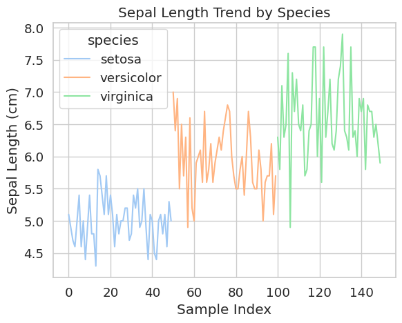

```python
# 使用 lineplot 绘制折线图
# 参数说明：
#   data：传入的数据框（DataFrame）
#   x：横轴变量，这里使用索引（样本编号）
#   y：纵轴变量，这里使用花萼长度 sepal_length
#   hue：按照品种 species 区分不同的折线
sns.lineplot(data=df.reset_index(), x="index", y="sepal_length", hue="species")

# 添加标题与坐标轴标签
plt.title("Sepal Length Trend by Species")
plt.xlabel("Sample Index")
plt.ylabel("Sepal Length (cm)")

# 显示图形
plt.show()
```

## Part 3. 使用 Seaborn 绘图的完整流程与图表类型概览

Seaborn 的绘图流程非常清晰直观，结合 Pandas 的 DataFrame 使用效果最佳。相比 Matplotlib，Seaborn 更关注“基于数据”的表达，即只需指定字段名，而无需手动提取和构造列表。

### 3.1 Seaborn 绘图的一般流程

1. **导入库**
   - `import seaborn as sns`
   - 通常也会同时导入 Pandas 和 Matplotlib
2. **设置主题与样式（可选但推荐）**
   - 如：`sns.set_theme(style="whitegrid")`
3. **加载或读取数据**
   - 使用 `sns.load_dataset()` 读取内置数据，或 `pd.read_csv()` 读取外部 CSV 文件
4. **调用绘图函数**
   - 如：`sns.barplot()`、`sns.boxplot()` 等
   - 参数主要包括：`x`、`y`、`data`、`hue`（按类别上色）等
5. **微调与显示图像**
   - 可使用 `plt.title()`、`plt.xlabel()` 等函数进一步美化图形
   - Notebook 中会自动展示图形，非 Notebook 环境可使用 `plt.show()`

### Part 4.1 使用鸢尾花数据集绘制直方图

直方图（Histogram）用于展示连续型数值数据的分布情况，是探索变量分布形态（如偏态、集中程度、离散程度等）的重要工具。

在 Seaborn 中，可以使用 `sns.histplot()` 快速绘制直方图，并可选择是否叠加核密度估计（KDE）曲线来平滑显示数据分布趋势。

本例中，我们将以鸢尾花数据集中 `petal_length`（花瓣长度）字段为例，绘制其直方图，并观察其分布形态。

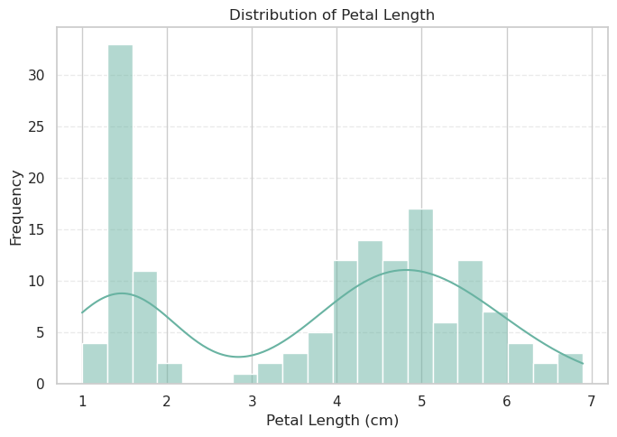

```python
import seaborn as sns
import pandas as pd
import matplotlib.pyplot as plt

# 加载内置的鸢尾花数据集
df = sns.load_dataset("iris")

# 设置 Seaborn 主题风格为白底带网格线
sns.set_theme(style="whitegrid")

# 绘制 petal_length 的直方图
# 参数说明：
#   data：传入的数据框
#   x：指定要绘制直方图的数值变量列名
#   bins：设置分箱数量（决定柱子的个数）
#   kde：是否绘制核密度估计曲线（平滑的分布曲线）
#   color：设置柱子的颜色
plt.figure(figsize=(7, 5))
sns.histplot(data=df, x="petal_length", bins=20, kde=True, color="#69b3a2")

# 添加图表标题与坐标轴标签
plt.title("Distribution of Petal Length")
plt.xlabel("Petal Length (cm)")
plt.ylabel("Frequency")

# 添加网格线
plt.grid(axis="y", linestyle="--", alpha=0.4)

# 展示图形
plt.tight_layout()
plt.show()
```

[figure not shown]

```python
# 使用 scatterplot 绘制散点图，展示 sepal_length 与 sepal_width 的关系
# hue：指定分类变量，用不同颜色表示不同品种
sns.scatterplot(data=df, x="sepal_length", y="sepal_width", hue="species")

# 添加标题与坐标轴标签
plt.title("Sepal Length vs Sepal Width")
plt.xlabel("Sepal Length (cm)")
plt.ylabel("Sepal Width (cm)")

# 显示图形
plt.show()
```

[output not shown]

### Part 4.2 使用鸢尾花数据集绘制箱线图

箱线图（Box Plot）是一种常用的统计图，用于展示数值变量的分布情况，包括中位数、上下四分位数以及异常值。

在 Seaborn 中，使用 `sns.boxplot()` 可以快速绘制分类变量对应的数值分布图。它特别适合用于对比多个类别在数值上的分布差异。

本例中，我们将比较不同品种鸢尾花的 `petal_width`（花瓣宽度）分布情况，观察是否存在明显的差异或异常值。

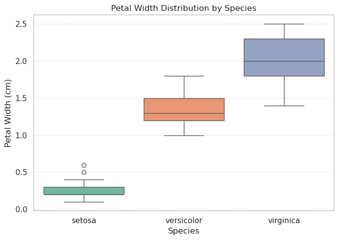

```python
import seaborn as sns
import pandas as pd
import matplotlib.pyplot as plt

# 加载鸢尾花数据集
df = sns.load_dataset("iris")

# 设置绘图风格
sns.set_theme(style="whitegrid")

# 绘制箱线图，使用 hue=species 解决 future warning，并关闭图例
plt.figure(figsize=(7, 5))
sns.boxplot(x="species", y="petal_width", hue="species", data=df, palette="Set2", legend=False)

# 添加标题和坐标轴标签
plt.title("Petal Width Distribution by Species")
plt.xlabel("Species")
plt.ylabel("Petal Width (cm)")

# 添加网格线
plt.grid(axis="y", linestyle="--", alpha=0.4)

# 显示图形
plt.tight_layout()
plt.show()
```

### Part 4.3 使用鸢尾花数据集绘制小提琴图

小提琴图（Violin Plot）结合了箱线图与核密度图的特点，不仅展示数据的中位数、四分位数和异常值，还能通过左右对称的形状反映数据分布的密度情况。

在 Seaborn 中，可以使用 `sns.violinplot()` 函数绘制小提琴图。它特别适合用于多个类别的数值变量分布对比，并观察其分布形态是否对称、是否集中或分散。

本例中，我们将比较不同品种鸢尾花的 `sepal_width`（花萼宽度）分布情况，观察各自的密度特征。

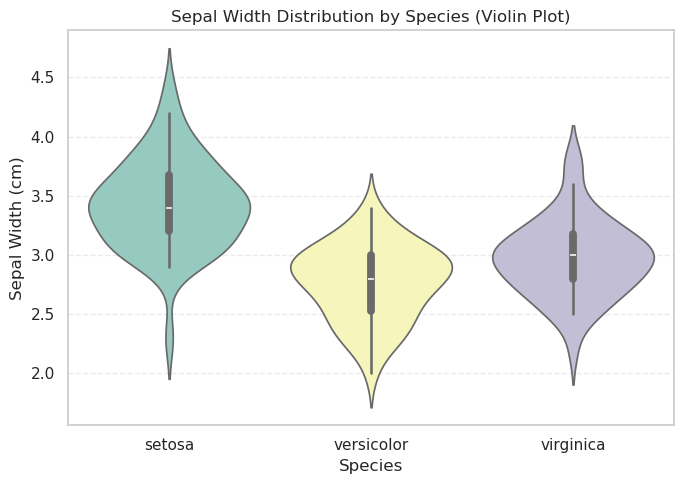

```python
import seaborn as sns
import pandas as pd
import matplotlib.pyplot as plt

# 加载鸢尾花数据集
df = sns.load_dataset("iris")

# 设置主题风格
sns.set_theme(style="whitegrid")

# 绘制小提琴图
# 参数说明：
#   x：分类变量，这里为品种（species）
#   y：数值变量，这里为花萼宽度（sepal_width）
#   data：数据框
#   inner：设置内部显示内容为 "box"，可同时显示箱线图
#   palette：设置调色板，hue 指定为 species 避免未来警告
plt.figure(figsize=(7, 5))
sns.violinplot(x="species", y="sepal_width", hue="species",
               data=df, inner="box", palette="Set3", legend=False)

# 添加标题与坐标轴标签
plt.title("Sepal Width Distribution by Species (Violin Plot)")
plt.xlabel("Species")
plt.ylabel("Sepal Width (cm)")

# 添加网格线
plt.grid(axis="y", linestyle="--", alpha=0.4)

# 显示图形
plt.tight_layout()
plt.show()
```

### Part 4.4 使用鸢尾花数据集绘制成对关系图

成对关系图（Pair Plot）用于展示多个数值变量之间的两两关系以及每个变量自身的分布情况。它在数据探索阶段（EDA）特别有用，可以快速帮助我们发现变量之间的相关性和分布结构。

在 Seaborn 中，可以使用 `sns.pairplot()` 一行代码绘制多个数值字段之间的成对图表。每一行和每一列代表一个变量，主对角线用于显示单个变量的分布，非对角线则是对应变量之间的散点图。

本例中，我们将对鸢尾花数据集中的 `sepal_length`、`sepal_width`、`petal_length` 三个字段绘制成对关系图，并使用品种 `species` 作为颜色分组变量。

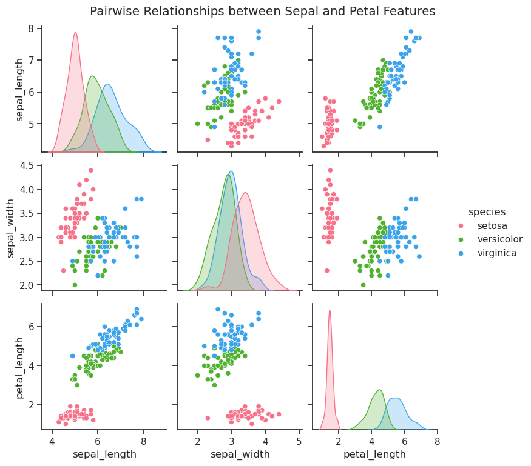

```python
import seaborn as sns
import pandas as pd
import matplotlib.pyplot as plt

# 加载鸢尾花数据集
df = sns.load_dataset("iris")

# 设置主题风格
sns.set_theme(style="ticks")

# 绘制成对关系图（pairplot）
# 参数说明：
#   data：数据框
#   vars：指定要展示的变量子集
#   hue：用于按品种上色
#   diag_kind：主对角线的展示方式（默认是直方图，可选 "kde"）
#   palette：设置配色方案
sns.pairplot(data=df,
             vars=["sepal_length", "sepal_width", "petal_length"],
             hue="species",
             diag_kind="kde",
             palette="husl")

# 添加整体标题（注意 pairplot 返回的是 Figure 对象，不能直接用 plt.title）
plt.suptitle("Pairwise Relationships between Sepal and Petal Features", y=1.02)

# 展示图形
plt.show()
```

### Part 4.5 使用鸢尾花数据集绘制热力图

热力图（Heatmap）是一种通过颜色的深浅来表示数值大小的图表，常用于展示矩阵结构的数据，特别是变量之间的相关性分析。

在 Seaborn 中，`sns.heatmap()` 可用于绘制二维数据的热力图，结合 Pandas 的 `.corr()` 方法，可以非常直观地展示数值变量之间的相关系数（取值范围 -1 到 1）。

本例中，我们将计算鸢尾花数据集中四个数值特征之间的相关系数，并以热力图形式展示出来，以便观察哪些变量之间具有较强的线性相关性。

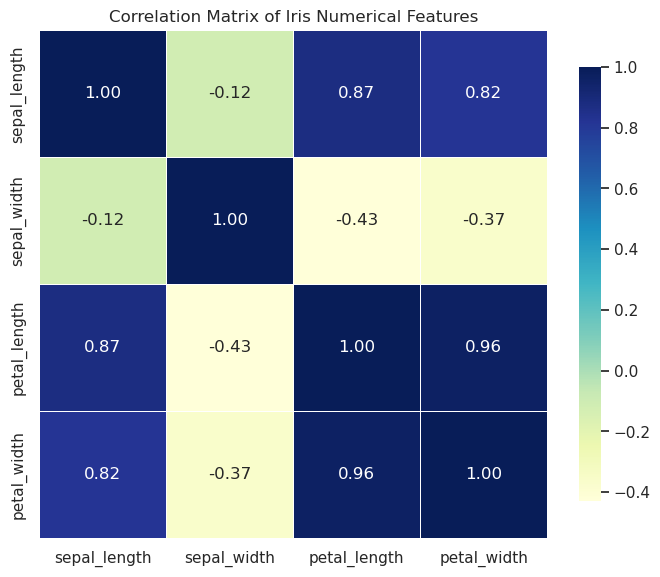

```python
import seaborn as sns
import pandas as pd
import matplotlib.pyplot as plt

# 加载鸢尾花数据集
df = sns.load_dataset("iris")

# 计算数值列之间的相关系数矩阵
corr_matrix = df.drop(columns=["species"]).corr()

# 设置主题风格
sns.set_theme(style="white")

# 绘制热力图
# 参数说明：
#   data：相关系数矩阵
#   annot：是否在图中标注数值
#   fmt：控制数值格式
#   cmap：设置颜色映射方案
#   square：将每个格子显示为正方形
#   linewidths：设置格子之间的分隔线宽度
plt.figure(figsize=(7, 6))
sns.heatmap(data=corr_matrix,
            annot=True,
            fmt=".2f",
            cmap="YlGnBu",
            square=True,
            linewidths=0.5,
            cbar_kws={"shrink": 0.8})

# 添加标题
plt.title("Correlation Matrix of Iris Numerical Features")

# 显示图形
plt.tight_layout()
plt.show()
```

## Part 5. 课堂练习：基于 Titanic 数据集的 Seaborn 可视化任务

请使用 Pandas 加载 Titanic 数据集（可通过 `sns.load_dataset("titanic")` 获取），使用 Seaborn 提供的函数完成以下图表绘制任务，全面复习前面所学的图形类型与参数设置方法。

每道题都指定了图表类型、分析字段和目标，练习难度由浅入深，建议按顺序完成。绘图时请注意添加标题、坐标轴标签和合适的调色方案，保证图表美观、清晰、具有解释性。

### 练习任务：

1. **直方图（`histplot`）**  
   绘制 `fare`（票价）的分布直方图，观察大多数乘客所支付的票价范围
   - x 轴：`fare`
   - 添加参数：`bins=30`, `kde=True`
2. **箱线图（`boxplot`）**  
   展示不同性别（`sex`）乘客的年龄（`age`）分布
   - x 轴：`sex`
   - y 轴：`age`
   - palette 可自定义为 `"Set2"`
3. **小提琴图（`violinplot`）**  
   比较不同登船港口（`embarked`）乘客的票价（`fare`）分布
   - x 轴：`embarked`
   - y 轴：`fare`
   - inner="box"，显示箱线图叠加
4. **热力图（`heatmap`）**  
   分析 Titanic 数值字段之间的相关性（例如 `age`、`fare`、`pclass`、`sibsp`、`parch` 等）
   - 使用 `df.corr()` 获取相关系数矩阵
   - 在热力图中显示数值（`annot=True`）
5. **成对关系图（`pairplot`）**  
   分析数值变量之间的成对关系，按是否生还（`survived`）分类上色
   - 选择字段：`age`、`fare`、`pclass`、`survived`
   - hue 设置为 `survived`，颜色区分生还/未生还乘客
   - diag_kind 设置为 `"kde"`

> 💡 如遇函数或参数不清楚，可参考官方文档或菜鸟教程：  
> https://www.runoob.com/matplotlib/seaborn-tutorial.html

> https://seaborn.pydata.org/tutorial/introduction.html